# R for Beginners

[output not shown]

# R Graphics

## The Graphic Environment

R comes with a wide variety of graphical functions. The R default graphics package provide standard R graphics. Additional libraries such as `lattice` and `ggplot` provide specialized and often very attractive graphics. This chapter is mainly about classical R graphics. Introductory examples of `lattice` and `ggplot2` graphics will be provided at the end of this chapter.

The graphical functions in the base R system, can be divided into two groups:

- High level plot functions. These functions produce “complete” graphics and will erase existing plots if not specified otherwise.
- Low level plot functions. These functions are used to add graphical objects like lines, points and texts to existing plots.

Generally, high level graphic functions are named according to the corresponding graphics. Simple examples are: `barplot()`, `boxplot()`, `pie()`.

A special case is the `plot()` function. This function is a generic function and perform differently according to its arguments or, more precisely, according to the class of the objects passed as arguments.

As a results:

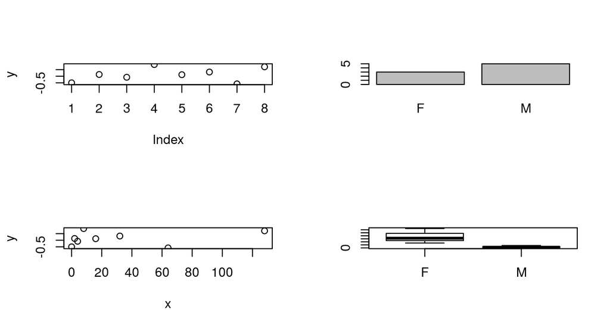

```r
f = factor(c("M", "M", "M", "M", "M", "F", "F","F"))
y = rnorm(8)
x = c(0, 2, 4, 8, 16, 32, 64, 128)
par(mfrow = c(2, 2))
plot(y)
plot(f)
plot(x, y)
plot(f, x)
```

## Scatterplot

The scatter plot (or scattergraph) is the main tool for the study of bivariate numerical distributions. $(x_1, y_1), \dots, (x_n, y_n)$ indicate the sets of data obtained from the X, Y numeric variables. The scatter plot is a graph where the points $P_1 = (x_1, y_1), \dots, P_n = (x_n, y_n)$ are defined in a Cartesian coordinate system. The features of the point cloud, such as location, internal cohesion, direction, and presence of isolated points, enable the deduction of the distribution statistical characteristics (position, dispersion, correlation, anomalous data).

Generally, the `plot()` function is called to produce simple scatter plot:

```r
load("states.Rda")
str(states, vec.len = 2)
```

```
## 'data.frame':    50 obs. of  11 variables:
##  $ Population       : num  3615 365 ...
##  $ Income           : num  3624 6315 ...
##  $ Illiteracy       : num  2.1 1.5 1.8 1.9 1.1 ...
##  $ Life.Exp         : num  69 69.3 ...
##  $ Murder           : num  15.1 11.3 7.8 10.1 10.3 ...
##  $ HS.Grad          : num  41.3 66.7 58.1 39.9 62.6 ...
##  $ Frost            : num  20 152 15 65 20 ...
##  $ Area             : num  50708 566432 ...
##  $ state.name       : Factor w/ 50 levels "Alabama","Alaska",..: 1 2 3 4 5 ...
##  $ state.region     : Factor w/ 4 levels "Northeast","South",..: 2 4 4 2 4 ...
##  $ states.region.abb: Factor w/ 4 levels "N "," S","C",..: 2 4 4 2 4 ...
```

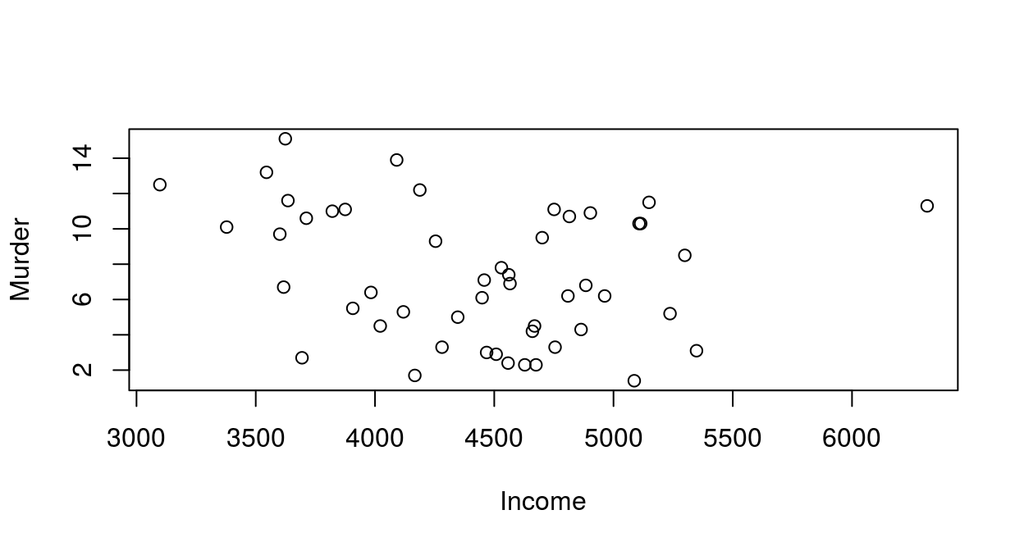

```r
with(states, plot (x = Income, y = Murder))
```

An alternative and more elegant way of calling the `plot()` function consist in specifying the `x` and `y` arguments by mean of a formula. Note that this method allows the data argument to be specified as an argument of the plot function.

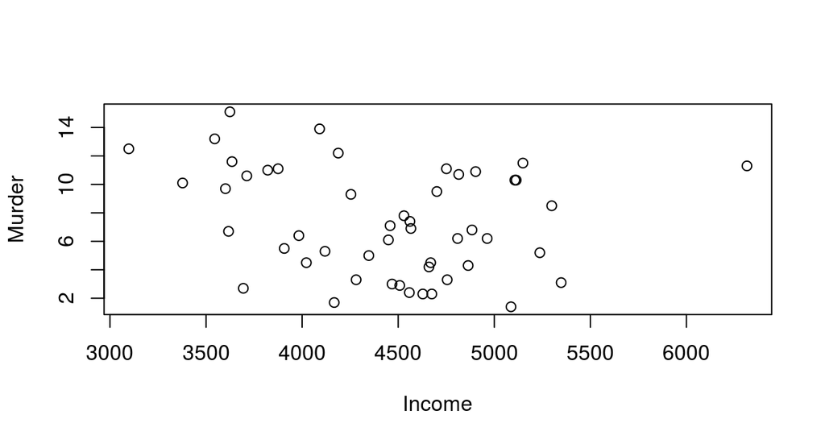

```r
plot(Murder ~ Income, data = states)
```

Some models differing from the basic plot are shown below.

- Addition of further elements, such as the centroid (the point whose coordinates are the arithmetic mean of X and Y, and the barycentre of the distribution), the least-squares line, particular concentration ellipses for the bivariate Gaussian distribution.
- Subordination: creation of a scatter plot of a set of variables for each level of the third subordinate variable.
- P-variate numerical distributions, $p > 2$: creation of a scatter plot matrix, a pxp square matrix, where the generic cell $(i, j)$ outside the main diagonal contains the scatter plot of the $i$ and $j$ variables, whereas the diagonal cells contain box-and-whiskers plots or histograms.

The scatter plot can be created with the `plot()` function (scatter plot for a set of variables), but also with `pairs()` (dispersion matrix) and `coplot()` (scatter plots of a set of variables for specified levels of a third alphanumeric or numeric variable). Moreover, the `locator()` and `identify()` functions enable the interactive use of the plot by adding further elements in the positions indicated by the mouse (locator) and underlying the index or the label of the point closest to the mouse pointer (identify). This function will not be discussed in this document.

### Type

When calling the `plot()` function, the argument type is set to its default: `type = "p"`. As a results graphics coordinates are represented by points (empty circles). Different graphical representations are given by: `"l"` for lines, `"o"` for overplotted points and lines, `"b"` for both points and lines, `"c"` for the lines parte alone of `"b"`, `"s"` and `"S"` for stair steps and `"h"` for histogram-like vertical lines. `type = "n"` is particularly important. In this case an empty plot with axes is created. The plot can be later customized in an extremely sophisticated way using more advanced graphic functions.

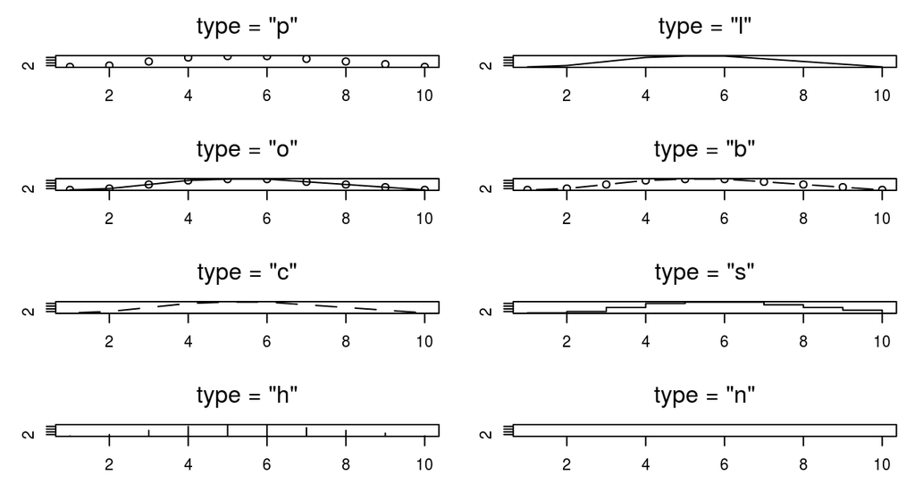

### Symbols

During the creation of the plot, the shape, the dimensions and the colour of the symbols can be customized with the pch, cex and col parameters respectively. An example of the implementation of these parameters inside `plot()` and the output graph are shown below.

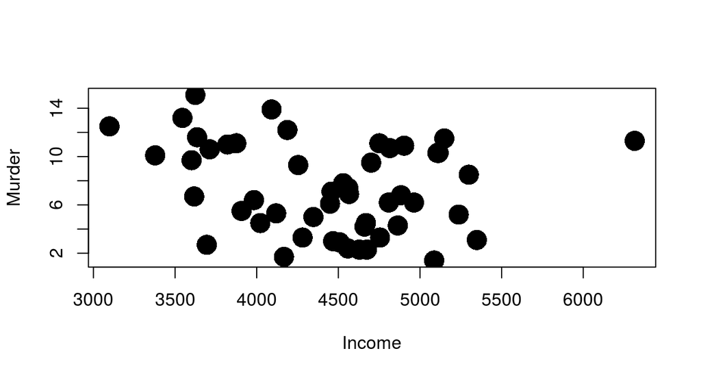

```r
plot(Murder ~ Income, data = states, pch = 16, cex = 2.5)
```

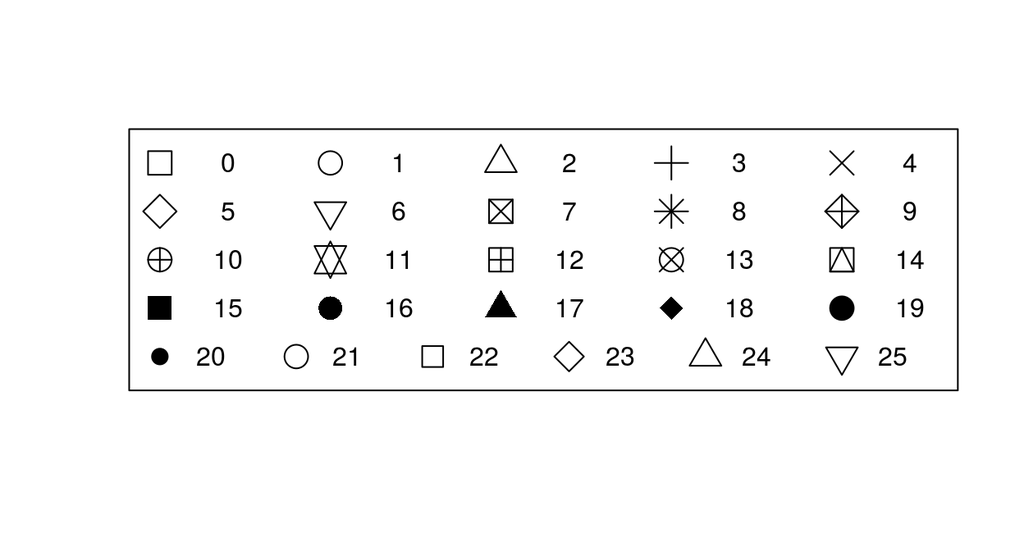

If you want to use a symbol which is not one of the standard 25, you can write it explicitly in the `pch` parameter. It needs to have only one character.

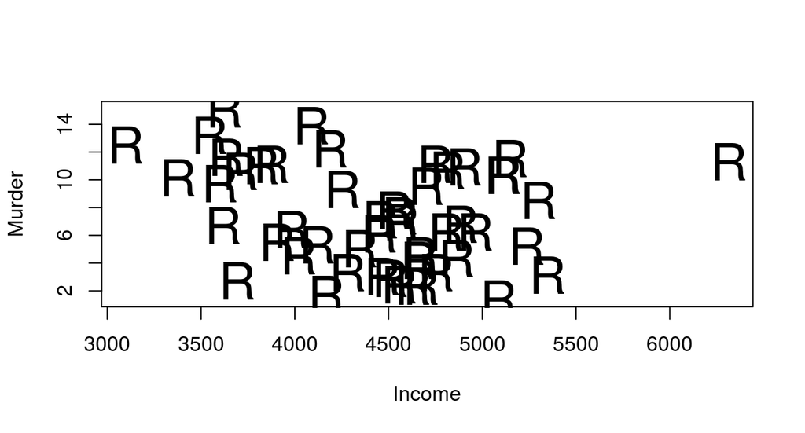

```r
plot(Murder ~ Income, data = states, pch = "R", cex = 2.5)
```

The `cex` parameter increases the dimension of the symbols as much as the parameter value.

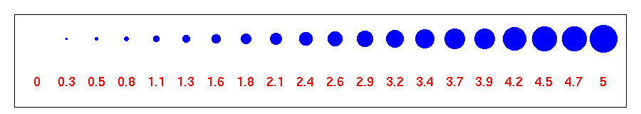

### Colours

In R the `col` parameter manages the colours of the symbols inside the plots. `col` can be defined in different ways. Some of these methods are as follows:

1. Specification of a number comprised between 1 and 8. In the graph above it is clear that these eight colours are repeated whenever there are multiples of eight.

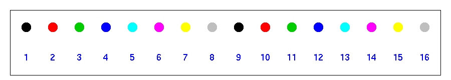

2. Specification of the name of the colour in English: red, blue, etc. There are 657 colours which can be defined in this way in R. For a complete list of available colours digit the `colors()` function, without arguments.
3. Use of the default colour sequence. These sequences are available thanks to some functions in which the input parameter specifies the number of colours to be extracted from the colour space. The above-mentioned functions are `rainbow()`, `heat.colors()`, `terrain.colors()`, `topo.colors()` and `cm.colors()`.

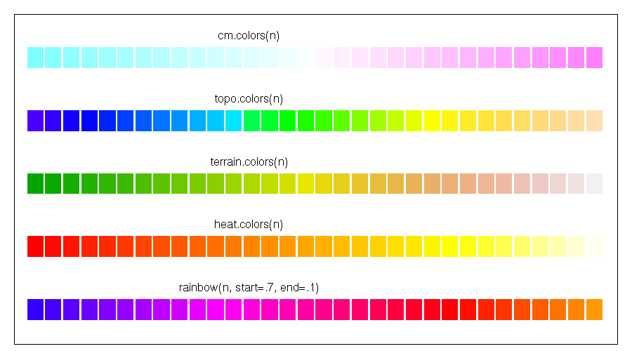

4. Specification of the colour in the hexadecimal format: #000000, #ffffff ecc.

### Titles

The main parameter of the `plot()` function enables the definition of the main title of the plot. This title will be displayed in the top centre of the plot. The sub parameter creates a subtitle which is displayed in the bottom centre of the plot. A title on two or more rows can be defined by inserting the special character “`\n`” in the title string. Finally, the `xlab` and `ylab` parameters change the titles of the x and y axes respectively.

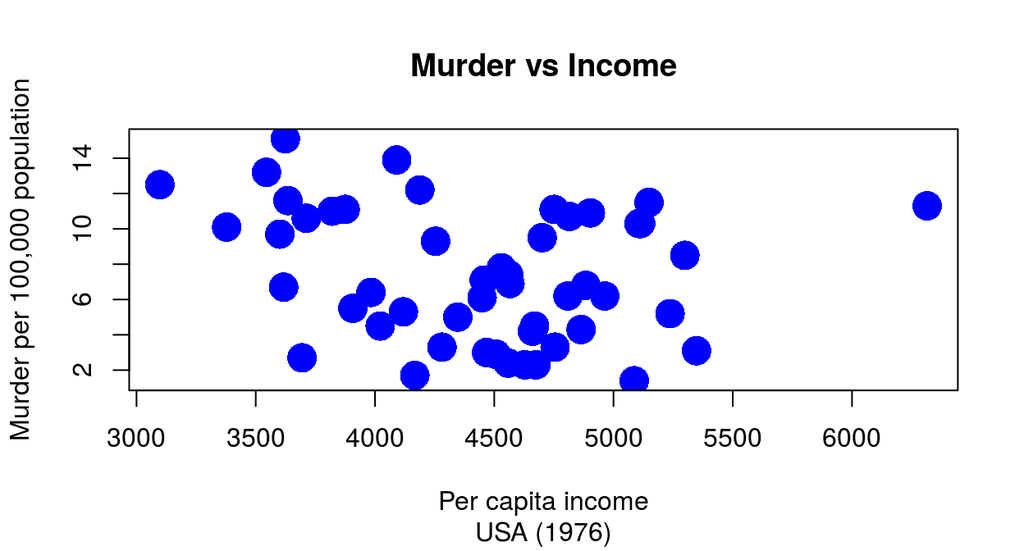

```r
plot(Murder ~ Income, data = states, pch = 16, col = "blue",
  cex = 2.5, main = "Murder vs Income", sub="USA (1976)",
  xlab = "Per capita income",
  ylab = "Murder per 100,000 population")
```

### Axes

The `xlim` parameter sets a range for the x-axis. The `ylim` parameter sets a range for the y-axis.

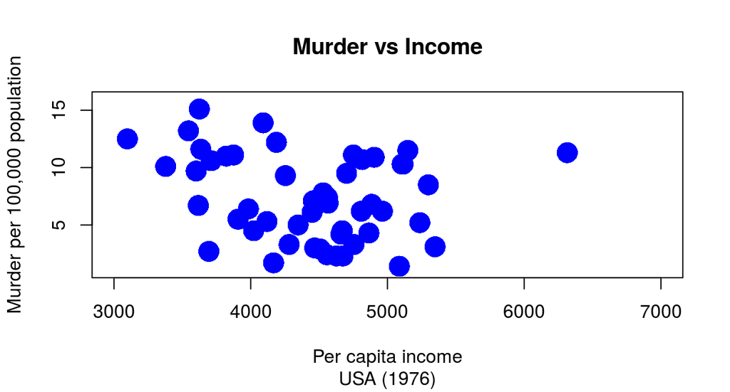

```r
plot(Murder ~ Income, data = states, pch = 16, col = "blue",
  cex = 2.5, main = "Murder vs Income", sub="USA (1976)",
  xlab = "Per capita income",
  ylab = "Murder per 100,000 population",
  xlim = c(3000, 7000), ylim = c(1, 16))
```

The axes can be set on a logarithmic scale with the `log` parameter. In particular, `log = "x"` and `log = "y"` set the x and y axes on a logarithmic base respectively. Use `log = "xy"` if both axes are to be logarithmic. In the Figure above the y-axis of the graph on the left is in natural scale, whereas the plot on the right shows a y-axis on a logarithmic scale. The graph on the right is generated by:

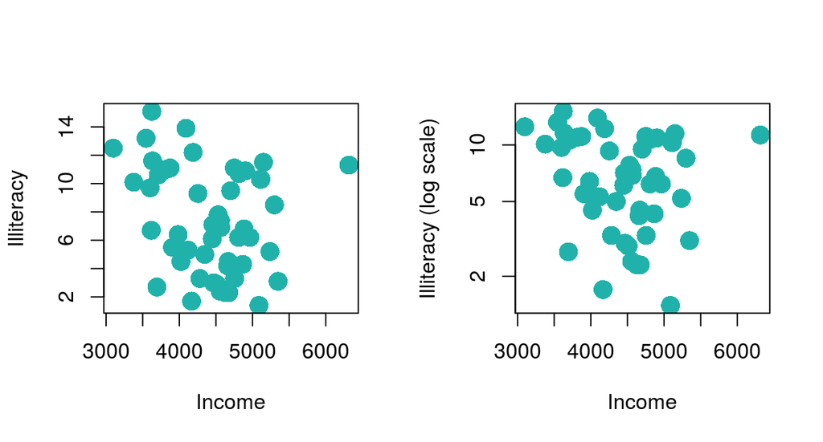

```r
plot(Murder ~ Income, data = states, pch = 16, cex = 2,
  col ="lightseagreen", ylab = "Illiteracy (log scale)", log = "y")
```

## Low-level Functions

So far the main parameters of the `plot()` functions have been dealt with. However, there are low-level functions which add information to top-level functions. Low-level functions only exist in association with a top-level function, which, in this case, is the `plot()` function. In the following paragraph it will be shown how some low-level functions can be used to improve the appearance of the graph and the information contained in the scatter plot.

### Text

A text can be inserted inside a scatter plot by specifying the coordinates. `text()` is a low-level function which introduces some text inside a graph. The input parameters of the `text()` function are:

- a vector with x coordinates $(x_1, \dots ,x_n)$,
- a vector with y coordinates $(y_1, \dots ,y_n)$,
- a vector with the text to be inserted.

Clearly, the three above-mentioned vectors need to have the same length. Therefore, the text in the $i$-th position will be inserted in the Cartesian coordinate system in $(xi, yi)$.

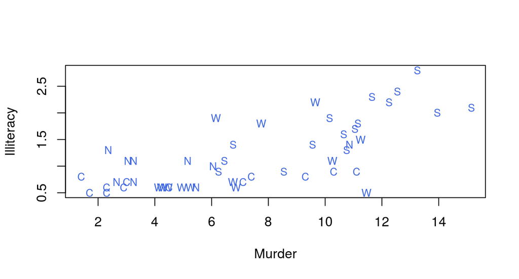

```r
plot(Illiteracy ~ Murder, data = states, type = "n")
text(Illiteracy ~ Murder, data = states,
  labels = states$states.region.abb, col = "royalblue", cex = 0.8)
```

In the Code below one of the arguments of the `text()` function is the `adj` parameter. The attribute of the `adj` parameter is a vector with two elements comprised between zero and one. These values indicate the horizontal and vertical alignment of the text (specified by `labels`) with its x and y coordinates. Some examples of alignment are reported below:

- `adj = c(0,0)` indicates an alignment on the bottom left.
- `adj = c(0.5,0.5)` indicates a central position compared with the x and y axes.
- `adj = c(1,1)` indicates an alignment on the top right.

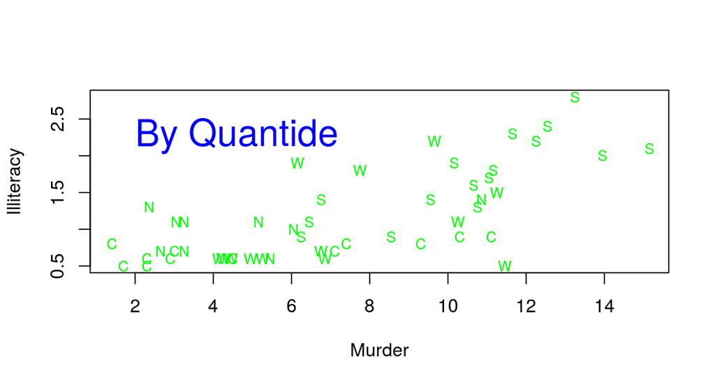

```r
plot(Illiteracy ~ Murder, data = states, type = "n")
text(Illiteracy ~ Murder, data = states, labels = states$states.region.abb,
  col = "green", cex = 0.8)
text(2, 2.5, labels = "By Quantide", adj = c(0, 1), col = "blue", cex = 2)
```